# Replicating UN Security Council Voting

Arthur Tartee

2023-05-08

## Installationi

You can install and load the following packages here or as you go along. I will point out in my code chunk when each will be needed:

```r
knitr::opts_chunk$set(echo = TRUE)

library(tidyverse)
library(magrittr)
library(tidyverse)
library(patchwork)
library(scales)
library(showtext)
library(extrafont)
install.packages("unvotes")
```

You can also download the dataset from [here](https://dataverse.harvard.edu/dataset.xhtml?persistentId=hdl:1902.1/12379):

Erik Voeten “Data and Analyses of Voting in the UN General Assembly” Routledge Handbook of International Organization, edited by Bob Reinalda (published May 27, 2013)

## Datasets

The package contains three datasets and you will need to load tidyverse here. First is the history of each country’s vote. These are represented in the `un_votes` dataset, with one row for each country/vote pair:

```r
library(tidyverse)
library(unvotes)
un_votes
```

```
## # A tibble: 869,937 × 4
##     rcid country            country_code vote
##    <dbl> <chr>              <chr>        <fct>
##  1     3 United States      US           yes
##  2     3 Canada             CA           no
##  3     3 Cuba               CU           yes
##  4     3 Haiti              HT           yes
##  5     3 Dominican Republic DO           yes
##  6     3 Mexico             MX           yes
##  7     3 Guatemala          GT           yes
##  8     3 Honduras           HN           yes
##  9     3 El Salvador        SV           yes
## 10     3 Nicaragua          NI           yes
## # ℹ 869,927 more rows
```

The package also contains a dataset of information about each roll call vote, including the date, description, and relevant resolution that was voted on:

```r
un_roll_calls
```

```
## # A tibble: 6,202 × 9
##     rcid session importantvote date       unres   amend  para short        descr
##    <int>   <dbl>         <int> <date>     <chr>   <int> <int> <chr>        <chr>
##  1     3       1             0 1946-01-01 R/1/66      1     0 AMENDMENTS,… "TO …
##  2     4       1             0 1946-01-02 R/1/79      0     0 SECURITY CO… "TO …
##  3     5       1             0 1946-01-04 R/1/98      0     0 VOTING PROC… "TO …
##  4     6       1             0 1946-01-04 R/1/107     0     0 DECLARATION… "TO …
##  5     7       1             0 1946-01-02 R/1/295     1     0 GENERAL ASS… "TO …
##  6     8       1             0 1946-01-05 R/1/297     1     0 ECOSOC POWE… "TO …
##  7     9       1             0 1946-02-05 R/1/329     0     0 POST-WAR RE… "TO …
##  8    10       1             0 1946-02-05 R/1/361     1     1 U.N. MEMBER… "TO …
##  9    11       1             0 1946-02-05 R/1/376     0     0 TRUSTEESHIP… "TO …
## 10    12       1             0 1946-02-06 R/1/394     1     1 COUNCIL MEM… "TO …
## # ℹ 6,192 more rows
```

Finally, the `un_roll_call_issues` dataset shows relationships betwen each vote and six issues - Arms control and disarmament,Economic development, Palestinian conflict, Human rights, Colonialism, and Nuclear weapons and nuclear material:

(Use `help()` to get information and documentation about each dataset).

### Example analysis

Many useful analyses will first involve joining the vote and roll call datasets by the shared `rcid` (roll call ID) column:

```r
joined = un_votes %>%
  inner_join(un_roll_calls, by = "rcid")

joined
```

```
## # A tibble: 869,937 × 12
##     rcid country country_code vote  session importantvote date       unres amend
##    <dbl> <chr>   <chr>        <fct>   <dbl>         <int> <date>     <chr> <int>
##  1     3 United… US           yes         1             0 1946-01-01 R/1/…     1
##  2     3 Canada  CA           no          1             0 1946-01-01 R/1/…     1
##  3     3 Cuba    CU           yes         1             0 1946-01-01 R/1/…     1
##  4     3 Haiti   HT           yes         1             0 1946-01-01 R/1/…     1
##  5     3 Domini… DO           yes         1             0 1946-01-01 R/1/…     1
##  6     3 Mexico  MX           yes         1             0 1946-01-01 R/1/…     1
##  7     3 Guatem… GT           yes         1             0 1946-01-01 R/1/…     1
##  8     3 Hondur… HN           yes         1             0 1946-01-01 R/1/…     1
##  9     3 El Sal… SV           yes         1             0 1946-01-01 R/1/…     1
## 10     3 Nicara… NI           yes         1             0 1946-01-01 R/1/…     1
## # ℹ 869,927 more rows
## # ℹ 3 more variables: para <int>, short <chr>, descr <chr>
```

One could then count how often each security council country votes “abstention” on a resolution in each year:

```r
library(lubridate)
by_country_year = joined %>%
  group_by(year = year(date), country) %>%
  summarize(votes = n(),
            percent_ab = mean(vote == "abstain"))
by_country_year
```

```
## # A tibble: 10,461 × 4
## # Groups:   year [73]
##     year country     votes percent_ab
##    <dbl> <chr>       <int>      <dbl>
##  1  1946 Afghanistan    17     0.412
##  2  1946 Argentina      43     0.0698
##  3  1946 Australia      43     0.0930
##  4  1946 Belarus        43     0.0233
##  5  1946 Belgium        43     0.116
##  6  1946 Bolivia        43     0.140
##  7  1946 Brazil         43     0.140
##  8  1946 Canada         42     0.0476
##  9  1946 Chile          43     0.163
## 10  1946 Colombia       42     0.381
## # ℹ 10,451 more rows
```

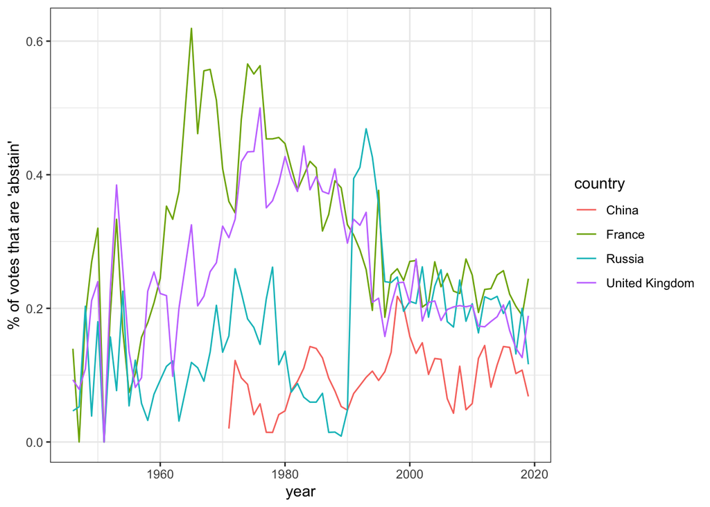

```r
theme_set(theme_bw())

countries <- c( "China", "France","Russia", "United Kingdom", "United States of America")

# there were fewer votes in 2013
by_country_year %>%
  filter(country %in% countries, year <= 2019) %>%
  ggplot(aes(year, percent_ab, color = country)) +
  geom_line() +
  ylab("% of votes that are 'abstain'")
```

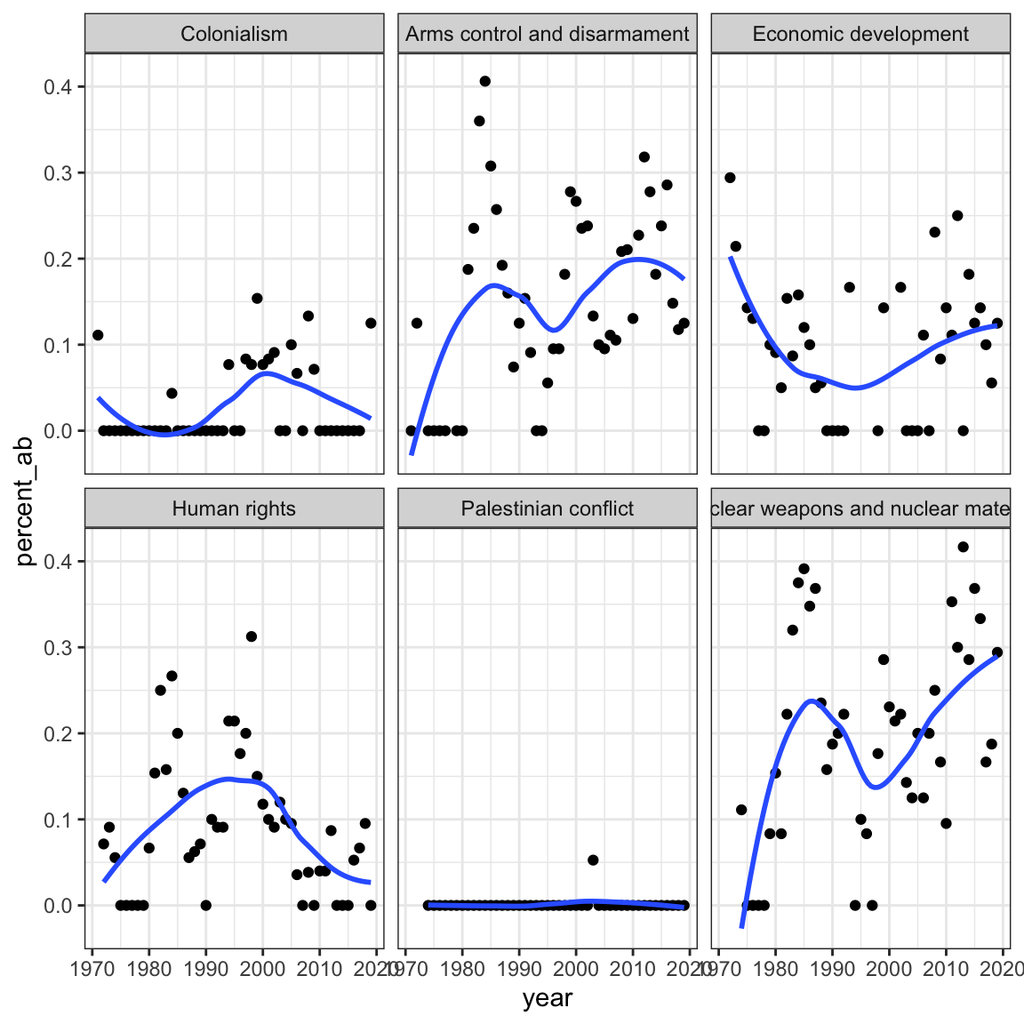

```r
joined %>%
  filter(country == "China") %>%
  inner_join(un_roll_call_issues, by = "rcid") %>%
  group_by(year = year(date), issue) %>%
  summarize(votes = n(),
            percent_ab = mean(vote == "abstain")) %>%
  filter(votes > 5) %>%
  ggplot(aes(year, percent_ab)) +
  geom_point() +
  geom_smooth(se = FALSE) +
  facet_wrap(~ issue)
```